# Risk Factor Analysis

## Outcome Variable

**Outcome Variable:** co_occurence

## Predictor Variables

**Intervention Variable:** ever_sunderweight06

**Adjustment Set:**

- sex
- arm
- brthmon
- single
- hhwealth_quart
- W_mage
- W_mhtcm
- W_meducyrs
- W_feducyrs
- delta_brthmon
- delta_single
- delta_hhwealth_quart
- delta_W_mage
- delta_W_mhtcm
- delta_W_meducyrs
- delta_W_feducyrs

## Stratifying Variables

The analysis was stratified on these variable(s):

- studyid
- country

## Data Summary

| studyid | country | ever_sunderweight06 | co_occurence | n_cell | n |
| --- | --- | --- | --- | --- | --- |
| CMC-V-BCS-2002 | INDIA | 0 | 0 | 286 | 369 |
| CMC-V-BCS-2002 | INDIA | 0 | 1 | 8 | 369 |
| CMC-V-BCS-2002 | INDIA | 1 | 0 | 61 | 369 |
| CMC-V-BCS-2002 | INDIA | 1 | 1 | 14 | 369 |
| CMIN | BANGLADESH | 0 | 0 | 178 | 237 |
| CMIN | BANGLADESH | 0 | 1 | 15 | 237 |
| CMIN | BANGLADESH | 1 | 0 | 33 | 237 |
| CMIN | BANGLADESH | 1 | 1 | 11 | 237 |
| COHORTS | GUATEMALA | 0 | 0 | 693 | 779 |
| COHORTS | GUATEMALA | 0 | 1 | 27 | 779 |
| COHORTS | GUATEMALA | 1 | 0 | 48 | 779 |
| COHORTS | GUATEMALA | 1 | 1 | 11 | 779 |
| COHORTS | PHILIPPINES | 0 | 0 | 2203 | 2487 |
| COHORTS | PHILIPPINES | 0 | 1 | 146 | 2487 |
| COHORTS | PHILIPPINES | 1 | 0 | 97 | 2487 |
| COHORTS | PHILIPPINES | 1 | 1 | 41 | 2487 |
| CONTENT | PERU | 0 | 0 | 198 | 200 |
| CONTENT | PERU | 0 | 1 | 0 | 200 |
| CONTENT | PERU | 1 | 0 | 2 | 200 |
| CONTENT | PERU | 1 | 1 | 0 | 200 |
| EE | PAKISTAN | 0 | 0 | 180 | 346 |
| EE | PAKISTAN | 0 | 1 | 22 | 346 |
| EE | PAKISTAN | 1 | 0 | 92 | 346 |
| EE | PAKISTAN | 1 | 1 | 52 | 346 |
| GMS-Nepal | NEPAL | 0 | 0 | 438 | 550 |
| GMS-Nepal | NEPAL | 0 | 1 | 37 | 550 |
| GMS-Nepal | NEPAL | 1 | 0 | 52 | 550 |
| GMS-Nepal | NEPAL | 1 | 1 | 23 | 550 |
| IRC | INDIA | 0 | 0 | 327 | 405 |
| IRC | INDIA | 0 | 1 | 15 | 405 |

[output cut: 78 more lines]

The following strata were considered:

- studyid: CMC-V-BCS-2002, country: INDIA
- studyid: CMIN, country: BANGLADESH
- studyid: COHORTS, country: GUATEMALA
- studyid: COHORTS, country: PHILIPPINES
- studyid: CONTENT, country: PERU
- studyid: EE, country: PAKISTAN
- studyid: GMS-Nepal, country: NEPAL
- studyid: IRC, country: INDIA
- studyid: JiVitA-4, country: BANGLADESH
- studyid: Keneba, country: GAMBIA
- studyid: LCNI-5, country: MALAWI
- studyid: MAL-ED, country: BANGLADESH
- studyid: MAL-ED, country: BRAZIL
- studyid: MAL-ED, country: INDIA
- studyid: MAL-ED, country: NEPAL
- studyid: MAL-ED, country: PERU
- studyid: MAL-ED, country: SOUTH AFRICA
- studyid: MAL-ED, country: TANZANIA, UNITED REPUBLIC OF
- studyid: NIH-Birth, country: BANGLADESH
- studyid: NIH-Crypto, country: BANGLADESH
- studyid: PROBIT, country: BELARUS
- studyid: PROVIDE, country: BANGLADESH
- studyid: ResPak, country: PAKISTAN
- studyid: SAS-CompFeed, country: INDIA
- studyid: SAS-FoodSuppl, country: INDIA
- studyid: TanzaniaChild2, country: TANZANIA, UNITED REPUBLIC OF
- studyid: ZVITAMBO, country: ZIMBABWE

### Dropped Strata

Some strata were dropped due to rare outcomes:

- studyid: CONTENT, country: PERU
- studyid: LCNI-5, country: MALAWI
- studyid: MAL-ED, country: BANGLADESH
- studyid: MAL-ED, country: BRAZIL
- studyid: MAL-ED, country: NEPAL
- studyid: MAL-ED, country: PERU
- studyid: MAL-ED, country: SOUTH AFRICA
- studyid: MAL-ED, country: TANZANIA, UNITED REPUBLIC OF
- studyid: PROBIT, country: BELARUS
- studyid: ResPak, country: PAKISTAN
- studyid: TanzaniaChild2, country: TANZANIA, UNITED REPUBLIC OF

## Methods Detail

We’re interested in the causal parameters $E[Y_a]$ for all values of $a \in \mathcal{A}$. These parameters represent the mean outcome if, possibly contrary to fact, we intervened to set all units to have $A=a$. Under the randomization and positivity assumptions, these are identified by the statistical parameters $\psi_a=E_W[E_{Y|A,W}(Y|A=a,W)]$. In addition, we’re interested in the mean of $Y$, $E[Y]$ under no intervention (the observed mean). We will estimate these parameters by using SuperLearner to fit the relevant likelihood factors – $E_{Y|A,W}(Y|A=a,W)$ and $p(A=a|W)$, and then updating our likelihood fit using a joint TMLE.

For unadjusted analyses ($W=\{\}$), initial likelihoods were estimated using Lrnr_glm to estimate the simple $E(Y|A)$ and Lrnr_mean to estimate $p(A)$. For adjusted analyses, a small library containing Lrnr_glmnet, Lrnr_xgboost, and Lrnr_mean was used.

Having estimated these parameters, we will then use the delta method to estimate relative risks and attributable risks relative to a prespecified baseline level of $A$.

# Results Detail

## Results Plots

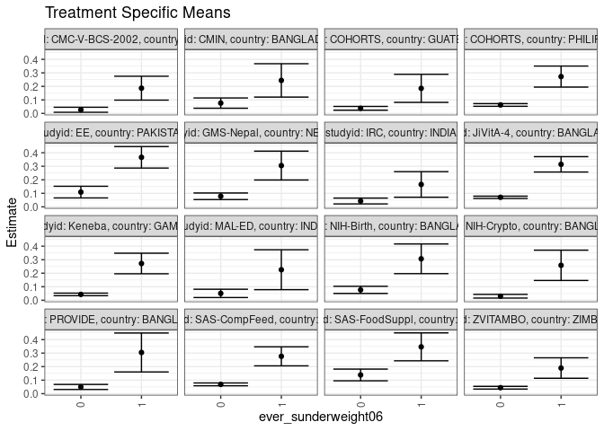

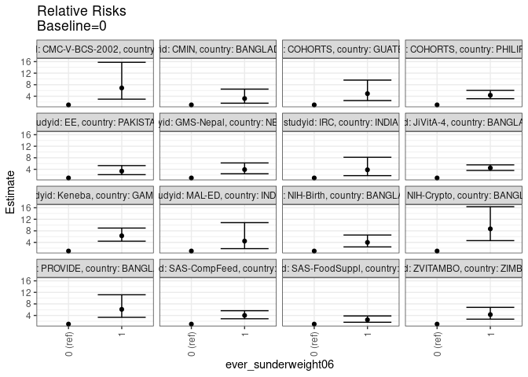

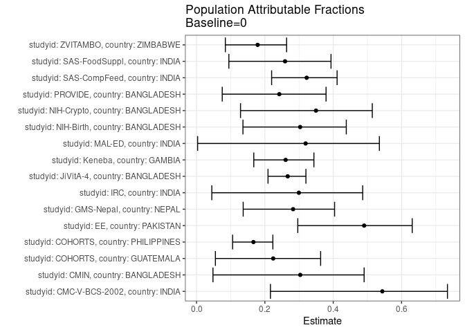

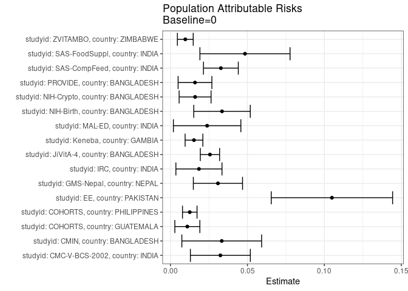

## Results Table

### Parameter: TSM

| studyid | country | intervention_level | baseline_level | estimate | ci_lower | ci_upper |
| --- | --- | --- | --- | --- | --- | --- |
| CMC-V-BCS-2002 | INDIA | 0 | NA | 0.0272109 | 0.0085881 | 0.0458337 |
| CMC-V-BCS-2002 | INDIA | 1 | NA | 0.1866667 | 0.0983639 | 0.2749695 |
| CMIN | BANGLADESH | 0 | NA | 0.0764077 | 0.0384166 | 0.1143989 |
| CMIN | BANGLADESH | 1 | NA | 0.2441319 | 0.1208071 | 0.3674567 |
| COHORTS | GUATEMALA | 0 | NA | 0.0378382 | 0.0237903 | 0.0518861 |
| COHORTS | GUATEMALA | 1 | NA | 0.1854166 | 0.0817507 | 0.2890825 |
| COHORTS | PHILIPPINES | 0 | NA | 0.0626706 | 0.0528980 | 0.0724432 |
| COHORTS | PHILIPPINES | 1 | NA | 0.2724178 | 0.1947129 | 0.3501226 |
| EE | PAKISTAN | 0 | NA | 0.1089699 | 0.0658112 | 0.1521286 |
| EE | PAKISTAN | 1 | NA | 0.3662956 | 0.2868033 | 0.4457880 |
| GMS-Nepal | NEPAL | 0 | NA | 0.0782613 | 0.0541083 | 0.1024143 |
| GMS-Nepal | NEPAL | 1 | NA | 0.3051348 | 0.1984939 | 0.4117758 |
| IRC | INDIA | 0 | NA | 0.0432460 | 0.0217652 | 0.0647268 |
| IRC | INDIA | 1 | NA | 0.1655217 | 0.0709378 | 0.2601055 |
| JiVitA-4 | BANGLADESH | 0 | NA | 0.0704741 | 0.0619816 | 0.0789667 |
| JiVitA-4 | BANGLADESH | 1 | NA | 0.3143583 | 0.2575581 | 0.3711586 |
| Keneba | GAMBIA | 0 | NA | 0.0432555 | 0.0337113 | 0.0527996 |
| Keneba | GAMBIA | 1 | NA | 0.2718388 | 0.1957702 | 0.3479074 |
| MAL-ED | INDIA | 0 | NA | 0.0507614 | 0.0200412 | 0.0814816 |
| MAL-ED | INDIA | 1 | NA | 0.2258065 | 0.0782988 | 0.3733141 |
| NIH-Birth | BANGLADESH | 0 | NA | 0.0769169 | 0.0504867 | 0.1033471 |
| NIH-Birth | BANGLADESH | 1 | NA | 0.3066497 | 0.1968882 | 0.4164111 |
| NIH-Crypto | BANGLADESH | 0 | NA | 0.0297559 | 0.0160377 | 0.0434741 |
| NIH-Crypto | BANGLADESH | 1 | NA | 0.2583742 | 0.1461989 | 0.3705496 |
| PROVIDE | BANGLADESH | 0 | NA | 0.0498033 | 0.0311499 | 0.0684568 |
| PROVIDE | BANGLADESH | 1 | NA | 0.3046282 | 0.1606291 | 0.4486273 |
| SAS-CompFeed | INDIA | 0 | NA | 0.0688482 | 0.0583698 | 0.0793267 |
| SAS-CompFeed | INDIA | 1 | NA | 0.2762252 | 0.2058203 | 0.3466301 |
| SAS-FoodSuppl | INDIA | 0 | NA | 0.1385087 | 0.0952607 | 0.1817567 |
| SAS-FoodSuppl | INDIA | 1 | NA | 0.3462157 | 0.2429497 | 0.4494816 |
| ZVITAMBO | ZIMBABWE | 0 | NA | 0.0441664 | 0.0340306 | 0.0543021 |
| ZVITAMBO | ZIMBABWE | 1 | NA | 0.1895099 | 0.1139444 | 0.2650755 |

### Parameter: E(Y)

| studyid | country | intervention_level | baseline_level | estimate | ci_lower | ci_upper |
| --- | --- | --- | --- | --- | --- | --- |
| CMC-V-BCS-2002 | INDIA | NA | NA | 0.0596206 | 0.0354285 | 0.0838127 |
| CMIN | BANGLADESH | NA | NA | 0.1097046 | 0.0698323 | 0.1495770 |
| COHORTS | GUATEMALA | NA | NA | 0.0487805 | 0.0336441 | 0.0639169 |
| COHORTS | PHILIPPINES | NA | NA | 0.0751910 | 0.0648251 | 0.0855569 |
| EE | PAKISTAN | NA | NA | 0.2138728 | 0.1706052 | 0.2571404 |
| GMS-Nepal | NEPAL | NA | NA | 0.1090909 | 0.0830130 | 0.1351688 |
| IRC | INDIA | NA | NA | 0.0617284 | 0.0382610 | 0.0851958 |
| JiVitA-4 | BANGLADESH | NA | NA | 0.0961073 | 0.0860713 | 0.1061434 |
| Keneba | GAMBIA | NA | NA | 0.0585078 | 0.0478474 | 0.0691682 |
| MAL-ED | INDIA | NA | NA | 0.0745614 | 0.0403897 | 0.1087331 |
| NIH-Birth | BANGLADESH | NA | NA | 0.1103896 | 0.0817833 | 0.1389959 |
| NIH-Crypto | BANGLADESH | NA | NA | 0.0457413 | 0.0294659 | 0.0620168 |
| PROVIDE | BANGLADESH | NA | NA | 0.0657194 | 0.0452330 | 0.0862057 |
| SAS-CompFeed | INDIA | NA | NA | 0.1015873 | 0.0902183 | 0.1129563 |
| SAS-FoodSuppl | INDIA | NA | NA | 0.1869159 | 0.1442025 | 0.2296293 |
| ZVITAMBO | ZIMBABWE | NA | NA | 0.0537825 | 0.0430304 | 0.0645346 |

### Parameter: RR

| studyid | country | intervention_level | baseline_level | estimate | ci_lower | ci_upper |
| --- | --- | --- | --- | --- | --- | --- |
| CMC-V-BCS-2002 | INDIA | 0 | 0 | 1.000000 | 1.000000 | 1.000000 |
| CMC-V-BCS-2002 | INDIA | 1 | 0 | 6.860000 | 2.985432 | 15.763079 |
| CMIN | BANGLADESH | 0 | 0 | 1.000000 | 1.000000 | 1.000000 |
| CMIN | BANGLADESH | 1 | 0 | 3.195121 | 1.579467 | 6.463445 |
| COHORTS | GUATEMALA | 0 | 0 | 1.000000 | 1.000000 | 1.000000 |
| COHORTS | GUATEMALA | 1 | 0 | 4.900245 | 2.504982 | 9.585860 |
| COHORTS | PHILIPPINES | 0 | 0 | 1.000000 | 1.000000 | 1.000000 |
| COHORTS | PHILIPPINES | 1 | 0 | 4.346821 | 3.140915 | 6.015717 |
| EE | PAKISTAN | 0 | 0 | 1.000000 | 1.000000 | 1.000000 |
| EE | PAKISTAN | 1 | 0 | 3.361439 | 2.140034 | 5.279950 |
| GMS-Nepal | NEPAL | 0 | 0 | 1.000000 | 1.000000 | 1.000000 |
| GMS-Nepal | NEPAL | 1 | 0 | 3.898925 | 2.445900 | 6.215143 |
| IRC | INDIA | 0 | 0 | 1.000000 | 1.000000 | 1.000000 |
| IRC | INDIA | 1 | 0 | 3.827441 | 1.794275 | 8.164471 |
| JiVitA-4 | BANGLADESH | 0 | 0 | 1.000000 | 1.000000 | 1.000000 |
| JiVitA-4 | BANGLADESH | 1 | 0 | 4.460620 | 3.594452 | 5.535512 |
| Keneba | GAMBIA | 0 | 0 | 1.000000 | 1.000000 | 1.000000 |
| Keneba | GAMBIA | 1 | 0 | 6.284495 | 4.408507 | 8.958788 |
| MAL-ED | INDIA | 0 | 0 | 1.000000 | 1.000000 | 1.000000 |
| MAL-ED | INDIA | 1 | 0 | 4.448387 | 1.825847 | 10.837790 |
| NIH-Birth | BANGLADESH | 0 | 0 | 1.000000 | 1.000000 | 1.000000 |
| NIH-Birth | BANGLADESH | 1 | 0 | 3.986767 | 2.425733 | 6.552374 |
| NIH-Crypto | BANGLADESH | 0 | 0 | 1.000000 | 1.000000 | 1.000000 |
| NIH-Crypto | BANGLADESH | 1 | 0 | 8.683129 | 4.609716 | 16.356046 |
| PROVIDE | BANGLADESH | 0 | 0 | 1.000000 | 1.000000 | 1.000000 |
| PROVIDE | BANGLADESH | 1 | 0 | 6.116622 | 3.350158 | 11.167553 |
| SAS-CompFeed | INDIA | 0 | 0 | 1.000000 | 1.000000 | 1.000000 |
| SAS-CompFeed | INDIA | 1 | 0 | 4.012089 | 2.853116 | 5.641852 |
| SAS-FoodSuppl | INDIA | 0 | 0 | 1.000000 | 1.000000 | 1.000000 |
| SAS-FoodSuppl | INDIA | 1 | 0 | 2.499595 | 1.634518 | 3.822516 |
| ZVITAMBO | ZIMBABWE | 0 | 0 | 1.000000 | 1.000000 | 1.000000 |
| ZVITAMBO | ZIMBABWE | 1 | 0 | 4.290819 | 2.707146 | 6.800936 |

### Parameter: PAR

| studyid | country | intervention_level | baseline_level | estimate | ci_lower | ci_upper |
| --- | --- | --- | --- | --- | --- | --- |
| CMC-V-BCS-2002 | INDIA | 0 | NA | 0.0324097 | 0.0129308 | 0.0518887 |
| CMIN | BANGLADESH | 0 | NA | 0.0332969 | 0.0073778 | 0.0592161 |
| COHORTS | GUATEMALA | 0 | NA | 0.0109423 | 0.0028122 | 0.0190724 |
| COHORTS | PHILIPPINES | 0 | NA | 0.0125204 | 0.0077976 | 0.0172433 |
| EE | PAKISTAN | 0 | NA | 0.1049030 | 0.0654601 | 0.1443458 |
| GMS-Nepal | NEPAL | 0 | NA | 0.0308296 | 0.0148410 | 0.0468183 |
| IRC | INDIA | 0 | NA | 0.0184824 | 0.0035004 | 0.0334643 |
| JiVitA-4 | BANGLADESH | 0 | NA | 0.0256332 | 0.0193658 | 0.0319006 |
| Keneba | GAMBIA | 0 | NA | 0.0152523 | 0.0094951 | 0.0210095 |
| MAL-ED | INDIA | 0 | NA | 0.0238000 | 0.0018774 | 0.0457226 |
| NIH-Birth | BANGLADESH | 0 | NA | 0.0334727 | 0.0150939 | 0.0518516 |
| NIH-Crypto | BANGLADESH | 0 | NA | 0.0159854 | 0.0056090 | 0.0263619 |
| PROVIDE | BANGLADESH | 0 | NA | 0.0159160 | 0.0049509 | 0.0268812 |
| SAS-CompFeed | INDIA | 0 | NA | 0.0327391 | 0.0214154 | 0.0440627 |
| SAS-FoodSuppl | INDIA | 0 | NA | 0.0484072 | 0.0191200 | 0.0776944 |
| ZVITAMBO | ZIMBABWE | 0 | NA | 0.0096161 | 0.0044701 | 0.0147622 |

### Parameter: PAF

| studyid | country | intervention_level | baseline_level | estimate | ci_lower | ci_upper |
| --- | --- | --- | --- | --- | --- | --- |
| CMC-V-BCS-2002 | INDIA | 0 | NA | 0.5435993 | 0.2162412 | 0.7342274 |
| CMIN | BANGLADESH | 0 | NA | 0.3035143 | 0.0480777 | 0.4904076 |
| COHORTS | GUATEMALA | 0 | NA | 0.2243164 | 0.0552318 | 0.3631399 |
| COHORTS | PHILIPPINES | 0 | NA | 0.1665149 | 0.1055370 | 0.2233358 |
| EE | PAKISTAN | 0 | NA | 0.4904922 | 0.2962722 | 0.6311099 |
| GMS-Nepal | NEPAL | 0 | NA | 0.2826050 | 0.1365284 | 0.4039694 |
| IRC | INDIA | 0 | NA | 0.2994142 | 0.0446709 | 0.4862288 |
| JiVitA-4 | BANGLADESH | 0 | NA | 0.2667143 | 0.2091763 | 0.3200660 |
| Keneba | GAMBIA | 0 | NA | 0.2606885 | 0.1675374 | 0.3434162 |
| MAL-ED | INDIA | 0 | NA | 0.3191998 | 0.0031572 | 0.5350431 |
| NIH-Birth | BANGLADESH | 0 | NA | 0.3032236 | 0.1358198 | 0.4381990 |
| NIH-Crypto | BANGLADESH | 0 | NA | 0.3494747 | 0.1287191 | 0.5142976 |
| PROVIDE | BANGLADESH | 0 | NA | 0.2421817 | 0.0751996 | 0.3790134 |
| SAS-CompFeed | INDIA | 0 | NA | 0.3222753 | 0.2197575 | 0.4113231 |
| SAS-FoodSuppl | INDIA | 0 | NA | 0.2589784 | 0.0946214 | 0.3934989 |
| ZVITAMBO | ZIMBABWE | 0 | NA | 0.1787967 | 0.0843004 | 0.2635413 |